# IODS course project

Laila Daniel

# About the IODS project

This project directory is for the course, Introduction to Open Data Science (IODS) at University of Helsinki, Spring 2017

[IODS-directory](https://github.com/ldaniel2016/IODS-project) is my github directory for the IODS project

[IODS-diary](https://ldaniel2016.github.io/IODS-project/) is my github diary for the IODS project

# Week 2: Rstudio Exercise 2 - Regression and model validation

The data, learn2014, is created using the R script in the Data wrangling exercise from the original data learning2014 available at http://www.helsinki.fi/~kvehkala/JYTmooc/JYTOPKYS3-data.txt.

The dataframe learn2014 has 166 observations and 7 variables.

We find in the first figure below, the graphical overview of the data variables, their distributions and relationships the colours in the plot is based on gender. The correlation between variables shows that the variable “attitude” is highly correlated to “points”. The next two variables correlated to “points” are “stra” and “surf” considering the absolute value of the correlation.

So we develop a linear regression model, my_model3, with three variables with the formula “points ~ attitude + stra + surf”. The summary of the my_model3 gives the coefficients of the variables and the Residual standard error as 5.296. The p-value is 3.156e-08.

As the residual error is smaller for my_model 2 and it has a p-value smaller than that of my_model3, we choose my_model2.

The plots show the Residuals vs Fitted values, Normal QQ-plot and Residuals vs Leverage. The Residuals vs Fitted values shows most of the residuals are along the mean value. The normal qq plot is linear and the leverage plot do not have outliers. These graphs show that the model is a good fit

```
## 'data.frame':    166 obs. of  7 variables:
##  $ gender  : Factor w/ 2 levels "F","M": 1 2 1 2 2 1 2 1 2 1 ...
##  $ age     : int  53 55 49 53 49 38 50 37 37 42 ...
##  $ attitude: num  3.7 3.1 2.5 3.5 3.7 3.8 3.5 2.9 3.8 2.1 ...
##  $ deep    : num  3.58 2.92 3.5 3.5 3.67 ...
##  $ stra    : num  3.38 2.75 3.62 3.12 3.62 ...
##  $ surf    : num  2.58 3.17 2.25 2.25 2.83 ...
##  $ points  : int  25 12 24 10 22 21 21 31 24 26 ...
```

```
## [1] 166   7
```

```
##   gender age attitude     deep  stra     surf points
## 1      F  53      3.7 3.583333 3.375 2.583333     25
## 2      M  55      3.1 2.916667 2.750 3.166667     12
## 3      F  49      2.5 3.500000 3.625 2.250000     24
## 4      M  53      3.5 3.500000 3.125 2.250000     10
## 5      M  49      3.7 3.666667 3.625 2.833333     22
## 6      F  38      3.8 4.750000 3.625 2.416667     21
```

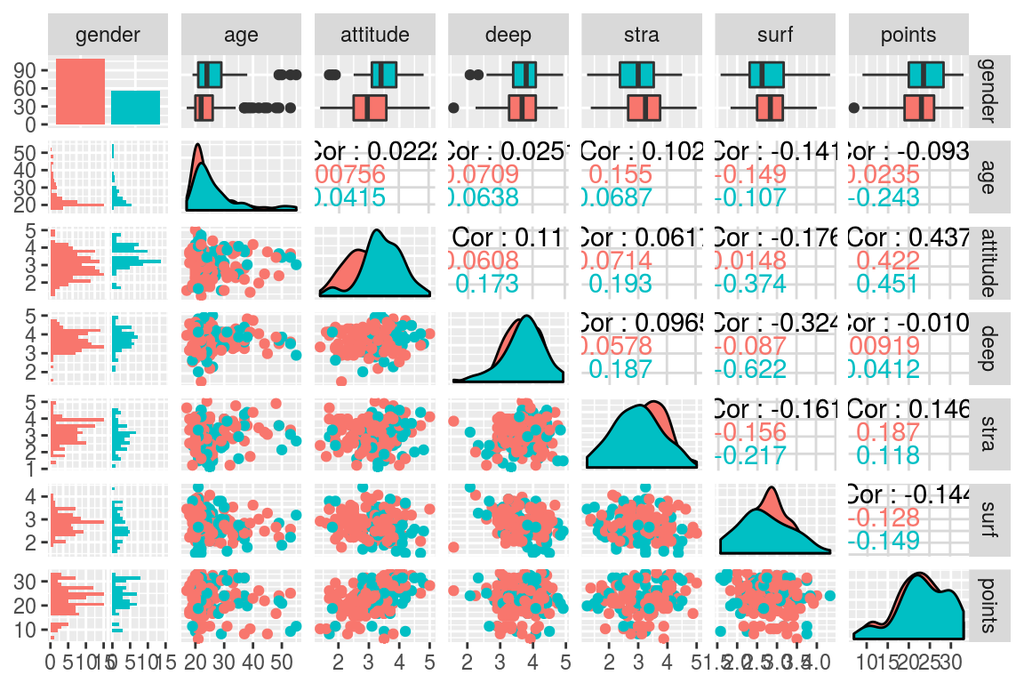

```
##
## Call:
## lm(formula = points ~ attitude + stra + surf, data = learn2014)
##
## Residuals:
##      Min       1Q   Median       3Q      Max
## -17.1550  -3.4346   0.5156   3.6401  10.8952
##
## Coefficients:
##             Estimate Std. Error t value Pr(>|t|)
## (Intercept)  11.0171     3.6837   2.991  0.00322 **
## attitude      3.3952     0.5741   5.913 1.93e-08 ***
## stra          0.8531     0.5416   1.575  0.11716
## surf         -0.5861     0.8014  -0.731  0.46563
## ---
## Signif. codes:  0 '***' 0.001 '**' 0.01 '*' 0.05 '.' 0.1 ' ' 1
##
## Residual standard error: 5.296 on 162 degrees of freedom
## Multiple R-squared:  0.2074, Adjusted R-squared:  0.1927
## F-statistic: 14.13 on 3 and 162 DF,  p-value: 3.156e-08
```

```
##
## Call:
## lm(formula = points ~ attitude + stra, data = learn2014)
##
## Residuals:
##      Min       1Q   Median       3Q      Max
## -17.6436  -3.3113   0.5575   3.7928  10.9295
##
## Coefficients:
##             Estimate Std. Error t value Pr(>|t|)
## (Intercept)   8.9729     2.3959   3.745  0.00025 ***
## attitude      3.4658     0.5652   6.132 6.31e-09 ***
## stra          0.9137     0.5345   1.709  0.08927 .
## ---
## Signif. codes:  0 '***' 0.001 '**' 0.01 '*' 0.05 '.' 0.1 ' ' 1
##
## Residual standard error: 5.289 on 163 degrees of freedom
## Multiple R-squared:  0.2048, Adjusted R-squared:  0.1951
## F-statistic: 20.99 on 2 and 163 DF,  p-value: 7.734e-09
```

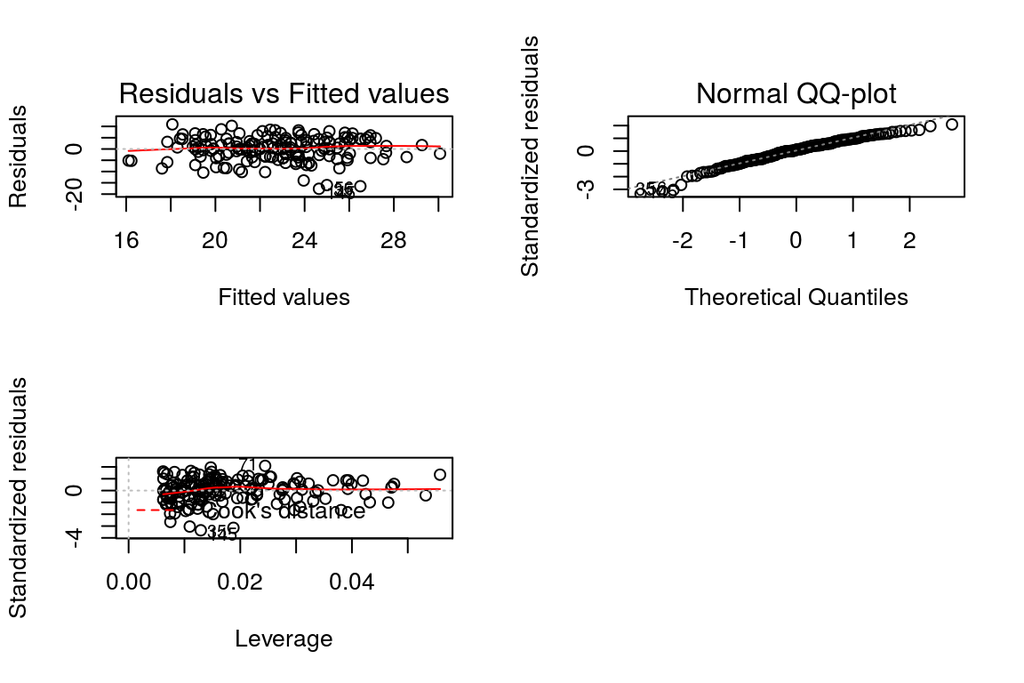

# Week 3: Rstudio Exercise 3- Logistic Regression

In this section we are analysing the datasets on student alcohol consumption in secondary school students in Portugal using Logistic regression.

The data from two questionnaires related to student alcohol consumption available at UCI Machine Learning Repository, [Student Alcohol consumption data page](https://archive.ics.uci.edu/ml/datasets/STUDENT+ALCOHOL+CONSUMPTION). The data consists of answers to two questionaires, one from math class and another from protugese class related to student alcohol consumption in secondary school students in Portugal.

The purpose of our analysis is to study the relationships between high/low alcohol consumption and some of the other variables in the data.

## The alc dataset

Using the program create_alc.R we joined the above two datsets to a new datset alc. The alc data set has two new columns alc_use, which is the average of weekday and weekend alcohol consumption and another column high_use which is true if alc_use > 2. This dataset is also available [here](http://s3.amazonaws.com/assets.datacamp.com/production/course_2218/datasets/alc.txt)

### The attributes of alc dataframe

1. school - student’s school (binary: ‘GP’ - Gabriel Pereira or ‘MS’ - Mousinho da Silveira)
2. sex - student’s sex (binary: ‘F’ - female or ‘M’ - male)
3. age - student’s age (numeric: from 15 to 22)
4. address - student’s home address type (binary: ‘U’ - urban or ‘R’ - rural)
5. famsize - family size (binary: ‘LE3’ - less or equal to 3 or ‘GT3’ - greater than 3)
6. Pstatus - parent’s cohabitation status (binary: ‘T’ - living together or ‘A’ - apart)
7. Medu - mother’s education (numeric: 0 - none, 1 - primary education (4th grade), 2 5th to 9th grade, 3 secondary education or 4 higher education)
8. Fedu - father’s education (numeric: 0 - none, 1 - primary education (4th grade), 2 5th to 9th grade, 3 secondary education or 4 higher education)
9. Mjob - mother’s job (nominal: ‘teacher’, ‘health’ care related, civil ‘services’ (e.g. administrative or police), ‘at_home’ or ‘other’)
10. Fjob - father’s job (nominal: ‘teacher’, ‘health’ care related, civil ‘services’ (e.g. administrative or police), ‘at_home’ or ‘other’)
11. reason - reason to choose this school (nominal: close to ‘home’, school ‘reputation’, ‘course’ preference or ‘other’)
12. guardian - student’s guardian (nominal: ‘mother’, ‘father’ or ‘other’)
13. traveltime - home to school travel time (numeric: 1 - <15 min., 2 - 15 to 30 min., 3 - 30 min. to 1 hour, or 4 - >1 hour)
14. studytime - weekly study time (numeric: 1 - <2 hours, 2 - 2 to 5 hours, 3 - 5 to 10 hours, or 4 - >10 hours)
15. failures - number of past class failures (numeric: n if 1<=n<3, else 4)
16. schoolsup - extra educational support (binary: yes or no)
17. famsup - family educational support (binary: yes or no)
18. paid - extra paid classes within the course subject (Math or Portuguese) (binary: yes or no)
19. activities - extra-curricular activities (binary: yes or no)
20. nursery - attended nursery school (binary: yes or no)
21. higher - wants to take higher education (binary: yes or no)
22. internet - Internet access at home (binary: yes or no)
23. romantic - with a romantic relationship (binary: yes or no)
24. famrel - quality of family relationships (numeric: from 1 - very bad to 5 - excellent)
25. freetime - free time after school (numeric: from 1 - very low to 5 - very high)
26. goout - going out with friends (numeric: from 1 - very low to 5 - very high)
27. Dalc - workday alcohol consumption (numeric: from 1 - very low to 5 - very high)
28. Walc - weekend alcohol consumption (numeric: from 1 - very low to 5 - very high)
29. health - current health status (numeric: from 1 - very bad to 5 - very good)
30. absences - number of school absences (numeric: from 0 to 93)
31. G1 - first period grade (numeric: from 0 to 20)
32. G2 - second period grade (numeric: from 0 to 20)
33. G3 - final grade (numeric: from 0 to 20, output target)
34. alc_use - average of weekday and weekend alcohol consumption
35. high_use is True if alc_use > 2

### 2. Reading the data to alc from amzonaws

```r
alc <- read.table("http://s3.amazonaws.com/assets.datacamp.com/production/course_2218/datasets/alc.txt",
                  sep = ",", header=TRUE)
dim(alc)
```

```
## [1] 382  35
```

```r
summary(alc)
```

```
##  school   sex          age        address famsize   Pstatus
##  GP:342   F:198   Min.   :15.00   R: 81   GT3:278   A: 38
##  MS: 40   M:184   1st Qu.:16.00   U:301   LE3:104   T:344
##                   Median :17.00
##                   Mean   :16.59
##                   3rd Qu.:17.00
##                   Max.   :22.00
##       Medu            Fedu             Mjob           Fjob
##  Min.   :0.000   Min.   :0.000   at_home : 53   at_home : 16
##  1st Qu.:2.000   1st Qu.:2.000   health  : 33   health  : 17
##  Median :3.000   Median :3.000   other   :138   other   :211
##  Mean   :2.806   Mean   :2.565   services: 96   services:107
##  3rd Qu.:4.000   3rd Qu.:4.000   teacher : 62   teacher : 31
##  Max.   :4.000   Max.   :4.000
##         reason    nursery   internet    guardian     traveltime
##  course    :140   no : 72   no : 58   father: 91   Min.   :1.000
##  home      :110   yes:310   yes:324   mother:275   1st Qu.:1.000
##  other     : 34                       other : 16   Median :1.000
##  reputation: 98                                    Mean   :1.442
##                                                    3rd Qu.:2.000
##                                                    Max.   :4.000
##    studytime        failures      schoolsup famsup     paid     activities
##  Min.   :1.000   Min.   :0.0000   no :331   no :144   no :205   no :181
##  1st Qu.:1.000   1st Qu.:0.0000   yes: 51   yes:238   yes:177   yes:201
##  Median :2.000   Median :0.0000
##  Mean   :2.034   Mean   :0.2906
##  3rd Qu.:2.000   3rd Qu.:0.0000
##  Max.   :4.000   Max.   :3.0000
##  higher    romantic      famrel        freetime         goout
##  no : 18   no :261   Min.   :1.00   Min.   :1.000   Min.   :1.000
##  yes:364   yes:121   1st Qu.:4.00   1st Qu.:3.000   1st Qu.:2.000
##                      Median :4.00   Median :3.000   Median :3.000
##                      Mean   :3.94   Mean   :3.223   Mean   :3.113
##                      3rd Qu.:5.00   3rd Qu.:4.000   3rd Qu.:4.000
##                      Max.   :5.00   Max.   :5.000   Max.   :5.000
##       Dalc            Walc          health         absences
##  Min.   :1.000   Min.   :1.00   Min.   :1.000   Min.   : 0.000
##  1st Qu.:1.000   1st Qu.:1.00   1st Qu.:3.000   1st Qu.: 0.000
##  Median :1.000   Median :2.00   Median :4.000   Median : 3.000
##  Mean   :1.474   Mean   :2.28   Mean   :3.579   Mean   : 5.319
##  3rd Qu.:2.000   3rd Qu.:3.00   3rd Qu.:5.000   3rd Qu.: 8.000
##  Max.   :5.000   Max.   :5.00   Max.   :5.000   Max.   :75.000
##        G1              G2              G3           alc_use
##  Min.   : 3.00   Min.   : 0.00   Min.   : 0.00   Min.   :1.000
##  1st Qu.: 8.00   1st Qu.: 8.25   1st Qu.: 8.00   1st Qu.:1.000
##  Median :10.50   Median :11.00   Median :11.00   Median :1.500
##  Mean   :10.86   Mean   :10.71   Mean   :10.39   Mean   :1.877
##  3rd Qu.:13.00   3rd Qu.:13.00   3rd Qu.:14.00   3rd Qu.:2.500
##  Max.   :19.00   Max.   :19.00   Max.   :20.00   Max.   :5.000
##   high_use
##  Mode :logical
##  FALSE:270
##  TRUE :112
##  NA's :0
##
##
```

The alc dataframe has 382 observations of 35 variables. The data is collected from 2 schools in Portugal from 382 students of which 198 are females and 184 are male students. The age of the students are ranging from 15 to 22. The variable ‘alc_use’ is the average of weekdays and weekend alcohol consumption and “high_use” is true if alc_use > 2.

The goal of this analysis is to find the relationship between “high_use” which is the predictand and the other variables in the dataset alc. We can use gather() to gather columns into key-value pairs and then glimpse() at the resulting data. We can see the distribution of the variables by drawing a bar plot using ggplot.

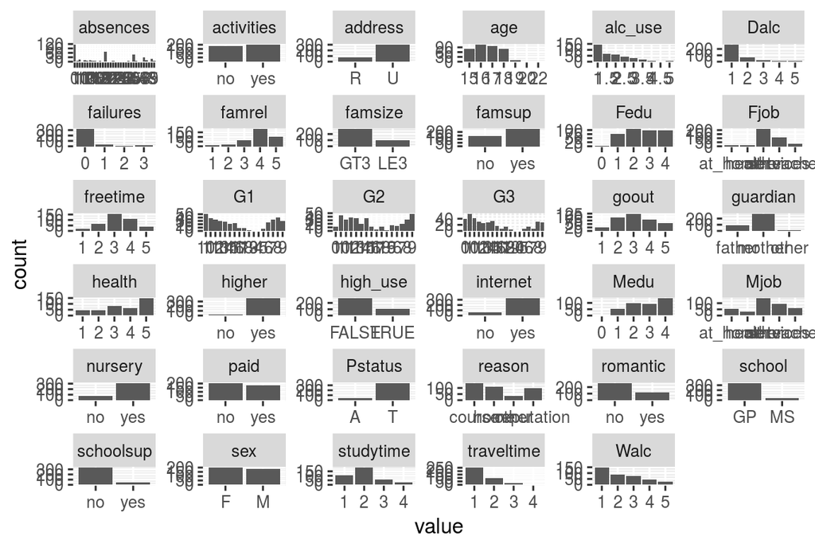

```r
library(tidyr); library(dplyr); library(ggplot2); library(GGally)
gather(alc) %>% ggplot(aes(value)) + facet_wrap("key", scales = "free") + geom_bar()
```

### Variable/attribute selection according to their influence on the high/low consumption of alcohol

The next step is to select the variables/attributes based on their influence on the high/low comsumption of alcohol.

This [page](https://www.r-bloggers.com/variable-importance-plot-and-variable-selection/) says that random forests can be used to find out the importance on the variables/attributes on the predictand.

The dataset alc we have 35 variables. From the alc dataset, we removed Dalc(workday alcohol consumption), Walc (weekend alcohol consumption), alc_use(average of weekday and weekend alcohol consumption) as the predictand high_use is calculated based on them. We also removed the G1(first period grade) and G2(second period grade) as the final grade G3 reflects the G1 and G2. Using randomForest package we can find the importance of the variables.

```r
library(randomForest)
# removing the Dalc, walc, G1, G2, alc_use coulumns from alc
alc_new <- alc[-c(27,28,31,32,34)]
fit=randomForest(factor(high_use)~., data=alc_new)
(VI_F=importance(fit))
```

```
##            MeanDecreaseGini
## school             1.160907
## sex                5.711111
## age                6.539719
## address            2.605542
## famsize            2.325420
## Pstatus            1.025382
## Medu               6.661041
## Fedu               5.667368
## Mjob               8.108583
## Fjob               5.238054
## reason             8.384073
## nursery            2.448327
## internet           1.358827
## guardian           3.262246
## traveltime         6.171004
## studytime          6.307158
## failures           4.248689
## schoolsup          1.460554
## famsup             2.638204
## paid               2.182817
## activities         2.574917
## higher             1.171901
## romantic           2.313188
## famrel             7.876283
## freetime           6.260447
## goout             18.128528
## health             6.295466
## absences          15.783543
## G3                12.050916
```

First, we find how the sex influence the alcohol consumption.

```r
alc %>% group_by(sex, high_use) %>% summarise(count = n())
```

```
## Source: local data frame [4 x 3]
## Groups: sex [?]
##
##      sex high_use count
##   <fctr>    <lgl> <int>
## 1      F    FALSE   157
## 2      F     TRUE    41
## 3      M    FALSE   113
## 4      M     TRUE    71
```

Clearly we can see that the number male students in the high_use group is more compared to female students.

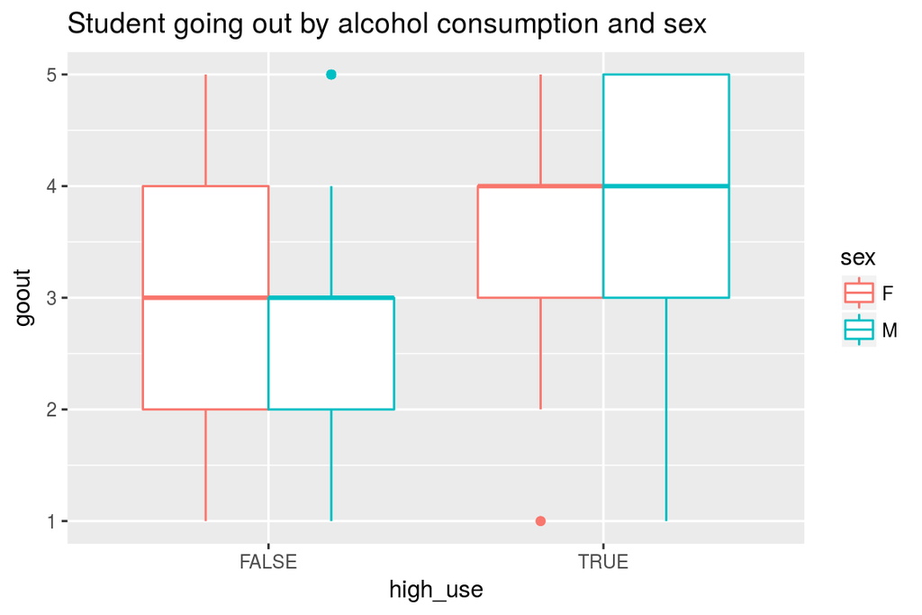

```r
# initialise a plot of high_use and gout
g2 <- ggplot(alc, aes(x = high_use, y = goout, col = sex))
# define the plot as a boxplot and draw it
g2 + geom_boxplot() + ylab("goout") + ggtitle("Student going out by alcohol consumption and sex" )
```

Among the male students, going out has a high mean value for the “high_use” group. So we select this variable

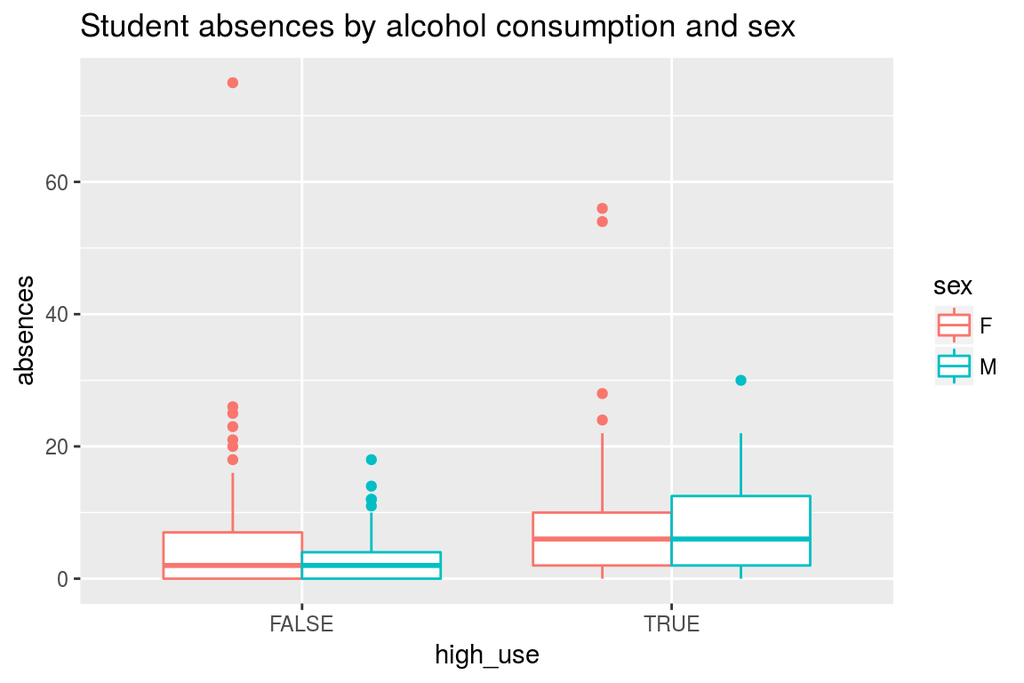

```r
# initialise a plot of high_use and absences
g2 <- ggplot(alc, aes(x = high_use, y = absences, col = sex))
# define the plot as a boxplot and draw it
g2 + geom_boxplot() + ylab("absences") + ggtitle("Student absences by alcohol consumption and sex" )
```

From the graph of Student absences by alcohol consumption and sex, “absences” have a high 75-percentile value “high_use” group. So we select this variable.

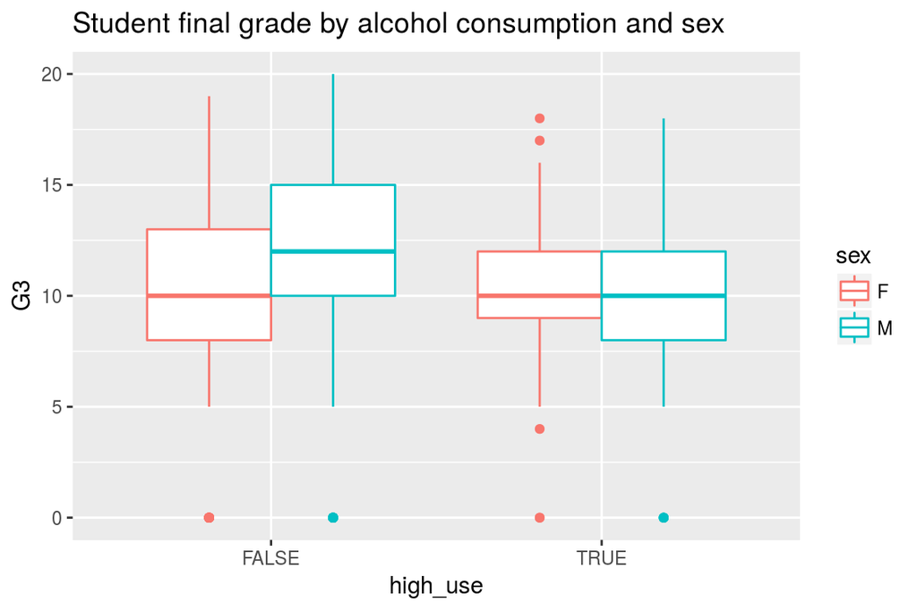

```r
# initialise a plot of high_use and G3
g2 <- ggplot(alc, aes(x = high_use, y = G3, col = sex))
# define the plot as a boxplot and draw it
g2 + geom_boxplot() + ylab("G3") + ggtitle("Student final grade by alcohol consumption and sex" )
```

From the Student G3(final grade) by alcohol consumption and sex graph we can observe that students with high_use of alcohol have low grades (mean and the quartile values) compared to low alcohol consumption group.

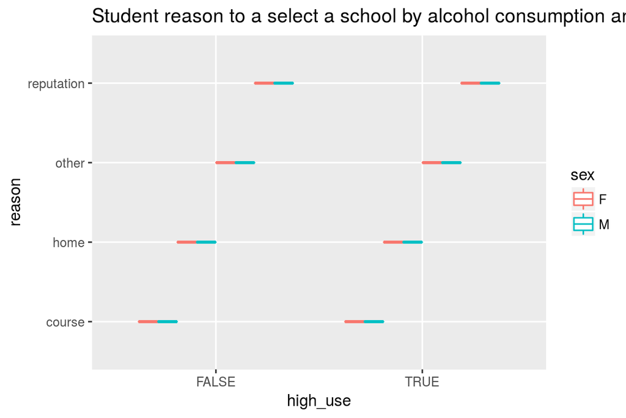

```r
# initialise a plot of high_use and reason
g2 <- ggplot(alc, aes(x = high_use, y = reason, col = sex))
# define the plot as a boxplot and draw it
g2 + geom_boxplot() + ylab("reason") + ggtitle("Student reason to a select a school by alcohol consumption and sex" )
```

We can observe that “reason to select a school” does not have any impact on the high_use of alcohol.

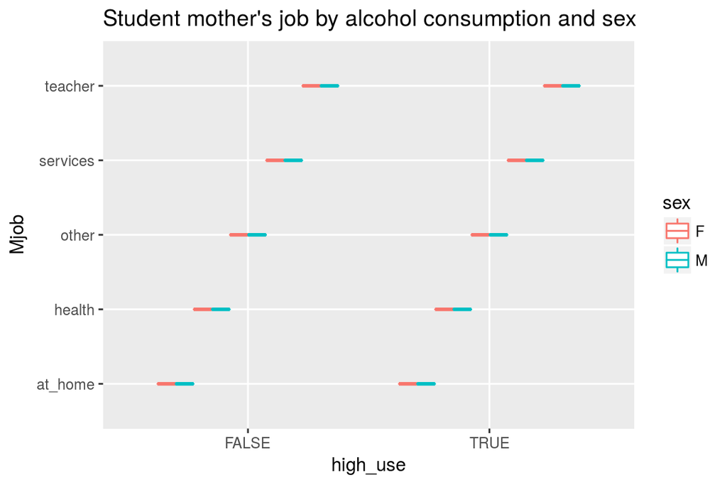

```r
# initialise a plot of high_use and Mjob
g2 <- ggplot(alc, aes(x = high_use, y = Mjob, col = sex))
# define the plot as a boxplot and draw it
g2 + geom_boxplot() + ylab("Mjob") + ggtitle("Student mother's job by alcohol consumption and sex" )
```

We can observe that the Mjob does not have any impact on the high_use of alcohol.

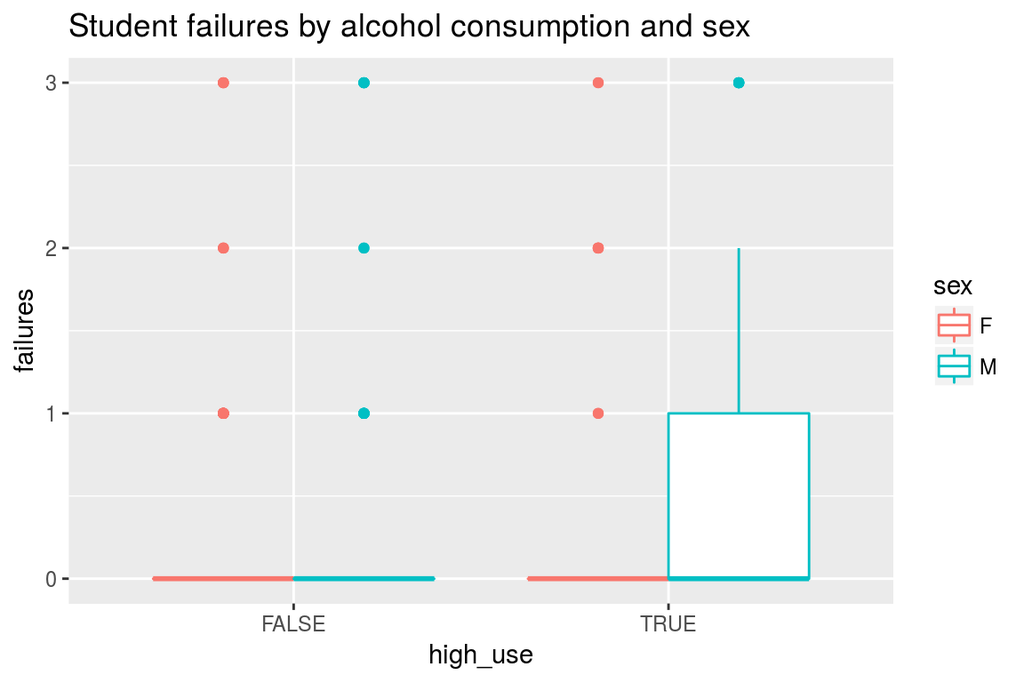

```r
# initialise a plot of high_use and failures
g2 <- ggplot(alc, aes(x = high_use, y = failures, col = sex))
# define the plot as a boxplot and draw it
g2 + geom_boxplot() + ylab("failures") + ggtitle("Student failures by alcohol consumption and sex" )
```

The above graph shows that student failures are affected by alcohol consumption for male students.

So we select the variables, “sex”“,”goout“,”absences“, failures as the impotant variables for our analysis. In otherwords we take predictand high_use and the explanatory variables are sex, gout, absences and failures.

### Find the model with glm() for logistic regression

```r
m <- glm(high_use ~ goout + failures + absences + sex, data = alc, family = "binomial")

# compute odds ratios (OR)
OR <- coef(m) %>% exp

# compute confidence intervals (CI)
CI <- confint(m) %>% exp

# print out the odds ratios with their confidence intervals
cbind(OR, CI)
```

```
##                     OR       2.5 %     97.5 %
## (Intercept) 0.01472214 0.005520616 0.03620626
## goout       2.04538456 1.623552039 2.61096941
## failures    1.33184898 0.949933462 1.86808335
## absences    1.06769512 1.035225148 1.10698949
## sexM        2.65567230 1.608518976 4.45004345
```

```r
cbind
```

```
## function (..., deparse.level = 1)
## .Internal(cbind(deparse.level, ...))
## <bytecode: 0x27cabf8>
## <environment: namespace:base>
```

```r
summary(m)
```

```
##
## Call:
## glm(formula = high_use ~ goout + failures + absences + sex, family = "binomial",
##     data = alc)
##
## Deviance Residuals:
##     Min       1Q   Median       3Q      Max
## -1.8046  -0.7661  -0.5196   0.7383   2.3862
##
## Coefficients:
##             Estimate Std. Error z value Pr(>|z|)
## (Intercept) -4.21840    0.47865  -8.813  < 2e-16 ***
## goout        0.71559    0.12089   5.919 3.24e-09 ***
## failures     0.28657    0.17170   1.669 0.095111 .
## absences     0.06550    0.01685   3.888 0.000101 ***
## sexM         0.97670    0.25898   3.771 0.000162 ***
## ---
## Signif. codes:  0 '***' 0.001 '**' 0.01 '*' 0.05 '.' 0.1 ' ' 1
##
## (Dispersion parameter for binomial family taken to be 1)
##
##     Null deviance: 462.21  on 381  degrees of freedom
## Residual deviance: 378.67  on 377  degrees of freedom
## AIC: 388.67
##
## Number of Fisher Scoring iterations: 4
```

The odds ratio OR measures the extend to which an explanatory variable influesnces the prediction of the predictand “high_use”. An OR value close to 1 signifies minimal influence whereas a higher OR value indicates a large influence. So we can see from our results that sex and gout have higher OR values than failures and absences.

From the confidence interval values, we observe that sexM (male) has the largest confidence interval. The difference between 25 percentile and 97.5 percentile values is around 3. The confidence interval values follows a decreasing order for goout, failures and absences. Both OR and Confidence interval show that sex and gout influences the predictand “high_use” compared to failures and absences.

To see the significance of the categorical predictor variable sex which has two factors male and female, we do the likelyhood test. We generate two models m1 and m2 where the model m1 includes the variable sex and model m2 does not include the variable sex.

```r
m1 <- glm(high_use ~ goout + failures + absences + sex, data = alc, family = "binomial")
m2 <- glm(high_use ~ goout + failures + absences , data = alc, family = "binomial")

anova(m1, m2, test="LRT")
```

```
## Analysis of Deviance Table
##
## Model 1: high_use ~ goout + failures + absences + sex
## Model 2: high_use ~ goout + failures + absences
##   Resid. Df Resid. Dev Df Deviance  Pr(>Chi)
## 1       377     378.67
## 2       378     393.47 -1  -14.803 0.0001194 ***
## ---
## Signif. codes:  0 '***' 0.001 '**' 0.01 '*' 0.05 '.' 0.1 ' ' 1
```

The likelihood ratio test shows that the variable sex is highly significant and we include it in the model.

### 6. predictive power of the model

Logistic regression gives binary predictions. The predict() function can be used to make predictions with a model object. Here we use the data alc to make the predictions for the predictand “high_use”.

```r
m <- glm(high_use ~ goout + failures + absences + sex, data = alc, family = "binomial")
# predict() the probability of high_use
probabilities <- predict(m, type = "response")

# add the predicted probabilities to 'alc'
alc <- mutate(alc, probability = probabilities)

# use the probabilities to make a prediction of high_use
alc <- mutate(alc, prediction = probability > 0.5)

# tabulate the target variable versus the predictions
table(high_use = alc$high_use, prediction = alc$prediction)
```

```
##         prediction
## high_use FALSE TRUE
##    FALSE   251   19
##    TRUE     62   50
```

Actually the high_use variable for the data alc has 270 FALSE values and 112 TRUE values. We apply logistic prediction using our model to the data alc, the table above shows the predictions for the variable “high_use. When high_use is false, the prediction states it is false for 251 and wrongly predict (gives TRUE) for 19 variables. Similarly when high_use is TRUE, 62 predictions state that it is FALSE and 50 state it is TRUE.We can see that the predictions for False values of high_use, the prediction is fairly accurate. For true values of high_use, the prediction below 50 %. We can see these results graphically.

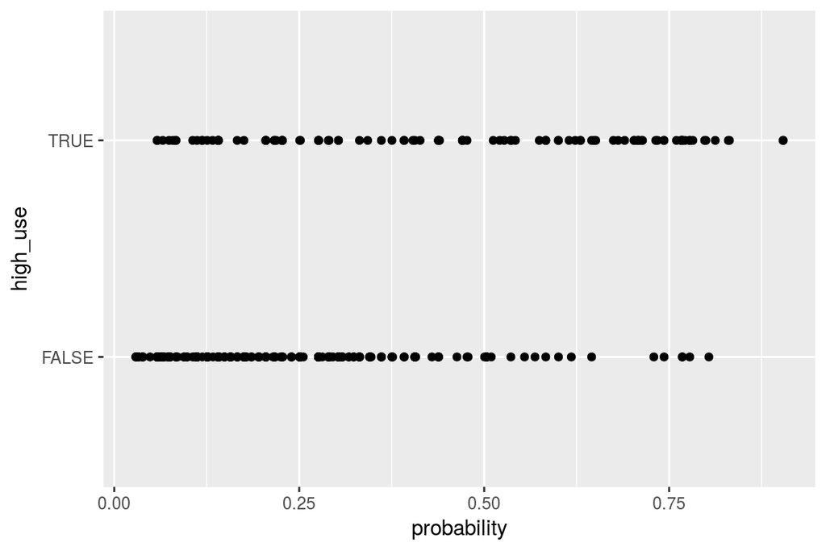

```r
# initialize a plot of 'high_use' versus 'probability' in 'alc'
g <- ggplot(alc, aes(x = probability, y = high_use))
g +  geom_point()
```

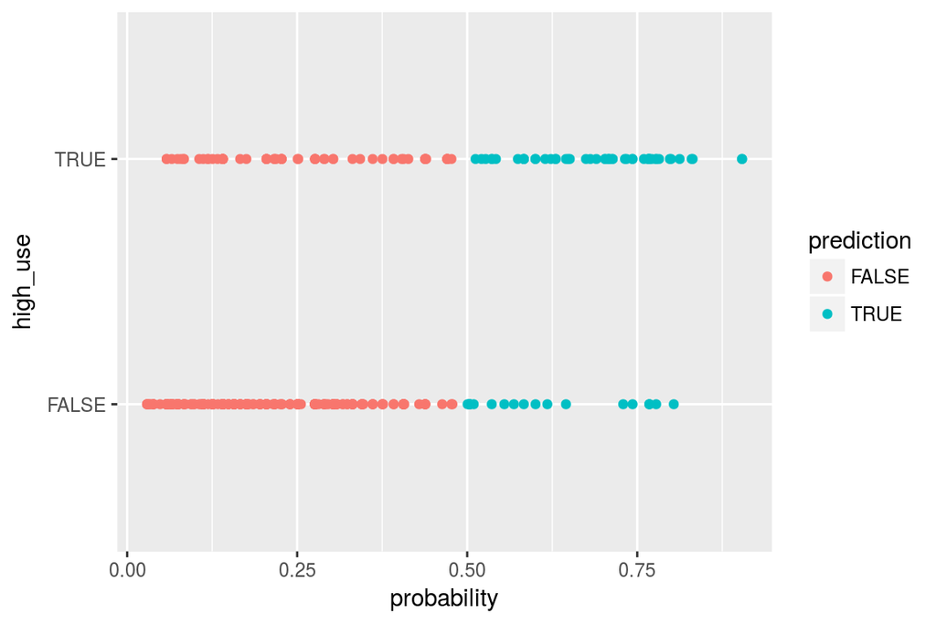

```r
# define the geom as points and draw the plot
g <- ggplot(alc, aes(x = probability, y = high_use, col = prediction))
g +  geom_point()
```

```r
# tabulate the target variable versus the predictions
table(high_use = alc$high_use, prediction = alc$prediction) %>% prop.table %>% addmargins
```

```
##         prediction
## high_use      FALSE       TRUE        Sum
##    FALSE 0.65706806 0.04973822 0.70680628
##    TRUE  0.16230366 0.13089005 0.29319372
##    Sum   0.81937173 0.18062827 1.00000000
```

In the Datacamp exercise where we take th model with only failure, absences and sex variables we get the following prediction for high_use

```r
# fit the model
m <- glm(high_use ~ failures + absences + sex, data = alc, family = "binomial")
probabilities <- predict(m, type = "response")

# add the predicted probabilities to 'alc'
alc <- mutate(alc, probability = probabilities)

# use the probabilities to make a prediction of high_use
alc <- mutate(alc, prediction = probability > 0.5)

# tabulate the target variable versus the predictions
table(high_use = alc$high_use, prediction = alc$prediction)
```

```
##         prediction
## high_use FALSE TRUE
##    FALSE   258   12
##    TRUE     86   26
```

So my model is better than Datacamp exercise model

### 7. Cross validation

Cross validation with k folds divides the dataset into k partitions. Each time it uses k-1 partition for trainining and one partition for test. This repeats in a round robin fashion

```r
# K-fold cross-validation
library(boot)
loss_func <- function(class, prob) {
  n_wrong <- abs(class - prob) > 0.5
  mean(n_wrong)
}
m<- glm(high_use ~ goout + failures + absences + sex, data = alc, family = "binomial")
# cross validation with K with the rownumber of alc. that means training takes n-1 rows of alc and test takes 1 row if the total number of rows are n
cv <- cv.glm(data = alc, cost = loss_func, glmfit = m, K = nrow(alc))

# average number of wrong predictions in the cross validation
cv$delta[1]
```

```
## [1] 0.2146597
```

```r
# 10-fold cross validation
cv<- cv.glm(data = alc, cost = loss_func, glmfit = m, K = 10)
cv$delta[1]
```

```
## [1] 0.2146597
```

### Perform cross-validation to compare the performance of different logistic regression models

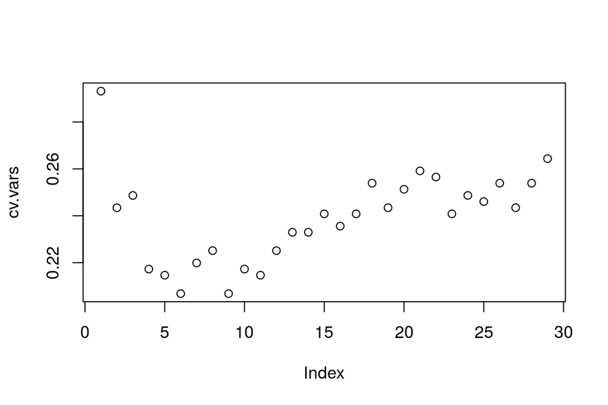

```r
cv.vars <- NULL

alc_vars <- c("sex", "absences", "failures" , "goout", "famrel", "G3","freetime","health", "school",
              "age","address","famsize","Pstatus","Medu","Fedu",
              "Mjob","Fjob","reason","nursery","internet","guardian","traveltime","studytime",
              "schoolsup", "famsup","paid","activities","higher","romantic")


library(boot)
loss_func <- function(class, prob) {
  n_wrong <- abs(class - prob) > 0.5
  mean(n_wrong)
}
for (i in 1:29) {
PredictorVariables <- paste(alc_vars[1:i], sep="")

formula_Vars <- formula(paste("high_use ~ ",
                         paste(PredictorVariables, collapse=" + ")))


m <- glm(formula_Vars, data = alc, family = "binomial")


# compute the average number of wrong predictions in the (training) data

loss_func(class = alc$high_use, prob = alc$probability)

# K-fold cross-validation

# 10-fold cross validation
cv<- cv.glm(data = alc, cost = loss_func, glmfit = m, K = 10)

cv$delta[1]
cv.vars <- rbind(cv.vars, cv$delta[1])
}

plot(cv.vars)
```